# Trabajo final Estadística Correlacional

Authors

Javiera Álvarez

Muriel Cantillana

Emilia Gallo

Camila Latorre

Alejandra Vega

# **Ansiedad y posibles factores estresores: Inseguridad Económica, Laboral y Trabajo Doméstico**

**Resumen**: Este estudio explora la relación entre la frecuencia de la ansiedad y tres factores clave: seguridad económica, estabilidad laboral y tiempo dedicado al trabajo doméstico, con un enfoque en las diferencias de género y las variaciones entre entornos urbanos y rurales. Los análisis estadísticos revelan que dificultades económicas, la percepción de inestabilidad laboral y la distribución desigual de las tareas no remuneradas se asocian con una mayor frecuencia de ansiedad, lo que resalta la asociación de estas variables con el bienestar psicológico.

**Introducción**

El presente estudio se enfoca en los problemas relacionados a la ansiedad y el estrés, y cómo estos malestares pueden verse influenciados por factores socioeconómicos y demográficos. Según el informe de la Organización Mundial de la Salud (OMS, 2017), más de un millón de chilenos padecen ansiedad y 850 mil tienen depresión, lo que sitúa al país en el cuarto lugar dentro de los países con mayor prevalencia de estos trastornos en la región de Las Américas. Asimismo, la Organización Panamericana de la Salud, expone en su estudio las cifras de ansiedad en la población chilena, en donde el 6,5% de la población mayor de 15 años -más de un millón de personas- sufren ansiedad a lo largo de su vida. De este porcentaje, el 17,7% de las mujeres sufren ansiedad frente al 9,5% de los hombres (INJUV, 2022).

Estas cifras reflejan un problema de salud pública que impacta a una proporción considerable de la población. La evidencia sugiere que la inestabilidad económica y la inseguridad están significativamente asociadas con un mayor riesgo de desarrollar síntomas de ansiedad, estrés y agotamiento físico y emocional (Londoño et al., 2010). Este fenómeno, además de afectar la salud individual, contribuye al aumento de las tasas de suicidio a nivel poblacional, lo que pone de manifiesto la urgencia de abordar esta crisis, la cual se ha convertido en un problema estructural que afecta a toda la sociedad (Vicente et al., 2016).

Es por estas razones que el presente estudio cobra relevancia al explorar cómo diversos factores, como la estabilidad económica, el género, el trabajo doméstico, la zona demográfica (urbana/rural) y el trabajo remunerado, se relacionan con el bienestar psicológico de las personas buscando ver si existe una verdadera relación entre estos factores y su magnitud.

**Conceptos clave**

Los conceptos claves a trabajar serán la ansiedad, el estrés a raíz de la inseguridad financiera y la carga del trabajo doméstico, con el fin de comprender los diversos ambientes en donde actúa la ansiedad.

El concepto central a tratar será la ansiedad, el cual comprenderemos como un sentimiento caracterizado por un miedo y preocupación excesiva que afecta en diferentes magnitudes el bienestar personal (OMS, 2022). Este puede verse influenciado por factores estresores que afectan a la vida de los sujetos, ligados tanto a la vida profesional como personal. De está forma, para comprender cómo los ámbitos socioeconómicos influyen en la ansiedad, se ahondará el concepto de ansiedad financiera, siendo está el miedo a no poder garantizar estabilidad, tanto en el presente como en el futuro, lo que impacta negativamente en la salud y bienestar individual, como en las dinámicas familiares y sociales (Alvarado y Alvarado-García, 2020).

De igual manera, otro factor influyente en el bienestar individual y vinculado a la ansiedad son las horas de trabajo doméstico. Refiriéndose al tiempo dedicado a un conjunto de actividades que se realizan en la esfera doméstica, destinadas a la satisfacción de necesidades de primer orden de los miembros de la unidad familiar, asignando un carácter obligatorio y de manera gratuita (Vega, 2007). Este concepto además de ser un factor estresor para todos los individuos, se caracteriza por ser diferenciado por género, donde las mujeres ocupadas, desocupadas o inactivas realizan al menos el doble de horas de trabajo no remunerado en comparación a los hombres. Con una distribución de 5,85 horas (99,1%) para las mujeres ocupadas, en comparación a 2,85 horas de realización de labores domésticas (94,4%) para los hombres. (ENUT, 2016).

Comprendiendo la ansiedad y sus factores, se analizará la relación entre los entornos urbanos y rurales en cuanto a su rol en el sentimiento de ansiedad de los individuos, considerando que el lugar de residencia puede influir en los niveles de bienestar emocional y psicológico debido a sus características. En este sentido, investigaciones como las de Torales et al. (2021) han mostrado que el entorno rural y urbano están significativamente asociados con sensaciones de ansiedad o depresión, evidenciando que el 77.59% de los participantes provenientes de zonas rurales experimentan malestares emocionales, en comparación con el 22.41% de los habitantes de zonas urbanas. Este análisis se complementa con los hallazgos de Londoño et al. (2010), quienes identificaron factores psicosociales y ambientales como determinantes en el desarrollo de trastornos mentales, destacando cómo las características del entorno influyen directamente en la salud emocional de los individuos.

**Objetivo general e hipótesis**

Esta investigación tiene como objetivo general analizar la relación entre la frecuencia de sentimientos de ansiedad, con la seguridad económica, la seguridad laboral y las horas de trabajo doméstico, también se tomará en cuenta el lugar de residencia para ver si existen diferencias entre los sectores urbanos y rurales.

1. Se plantea la hipótesis de que los niveles de ansiedad están relacionados con la dificultad para llegar a fin de mes, es decir, con la inseguridad económica.
2. Se plantea la hipótesis de que los niveles de ansiedad están asociados con la inestabilidad laboral, específicamente con el temor a perder el empleo.
3. Se plantea la hipótesis de que existen diferencias significativas en los niveles de ansiedad según el género, lo que podría reflejar desigualdades estructurales en las condiciones de vida y trabajo.
4. Se plantea la hipótesis de que un alto nivel de carga en el trabajo doméstico está asociado con mayores niveles de ansiedad.
5. Se plantea la hipótesis de que pueden haber diferencias con respecto a la frecuencia de ansiedad entre áreas rurales y urbanas.

**Metodología**

Para la investigación se utilizó la Encuesta de Bienestar Social (EBS) 2023 desarrollada por el Observatorio Social del Ministerio de Desarrollo Social y Familia. Esta encuesta evalúa 11 dimensiones del bienestar social general, que incluyen: bienestar subjetivo, educación, trabajo, uso del tiempo, ingresos, salud, vivienda, medio ambiente, seguridad, relaciones sociales, confianza y participación, y orientación sexual. Su principal objetivo es generar cifras oficiales sobre las condiciones que influyen en el bienestar de los ciudadanos, poniendo énfasis en las oportunidades que tienen las personas para desarrollar la vida que desean. Para este estudio, se utilizaron las dimensiones de salud, trabajo, relaciones sociales, ingresos y uso del tiempo, complementadas con variables de caracterización del módulo L, como edad, residencia y sexo.

```r
pacman::p_load(tidyverse, # Manipulacion datos
               sjPlot, # Graficos y tablas
               sjmisc, # Descriptivos
               corrplot, # Correlaciones
               psych, # Test estadísticos
               kableExtra,
               haven,
               broom,
               dplyr)
#Cargar base de datos desde files
load("~/Library/Mobile Documents/com~apple~CloudDocs/estadisticatrabajofinal/Base de datos EBS 2023.RData")

# Cargar y seleccionar variables de interés
ebs <- EBS_2023_vp %>%
  dplyr::select(
    sg01,          # Sexo
    glosa_area,    # Tipo de residencia (urbano/rural)
    ss7_c,         # Ansiedad
    oo7_a1,        # Riesgo de perder el trabajo
    yy2,           # Dificultad para llegar a fin de mes
    tdomestico     # Tiempo dedicado al trabajo doméstico (minutos)
  )
```

**Tabla 1. Listado de variables**

**Procedimiento y recodificaciones**

| **Variable** | **Nombre** | **Indicador** | **Nivel de medición** | **Valores de respuesta** |
| --- | --- | --- | --- | --- |
| **ss7_c** **(dependiente)** | Frecuencia de ansiedad: Se ha sentido nervioso(a)ansioso(a) o con los nervios de punta | Ansiedad | Ordinal tipo Likert | 1: Nunca 2: Algunos días 3: Más de la mitad de los días, 4: Casi todos los días. |
| **sg01 (independiente)** | Sexo | Datos sociodemográficos | Nominal dicotómica | 1: Masculino 2: Femenino |
| **glosa_area** **(independiente)** | Área de residencia | Datos sociodemográficos | Nominal dicotómica | 1: Urbano 2: Rural |
| **oo7_a1** **(independiente)** | Puede perder su trabajo en los próximos seis meses. | Inseguridad/inestabilidad laboral | Ordinal tipo Likert | 1: Muy en desacuerdo 2:En desacuerdo 3: Ni de acuerdo ni en desacuerdo 4: De acuerdo 5:Muy de acuerdo. |
| **yy2** **(independiente)** | ¿Su hogar puede llegar a fin de mes…? | Inseguridad económica | Ordinal tipo Likert | 1: Con mucha dificultad 2: Con dificultad 3: Ni con dificultad ni con facilidad 4: Con facilidad 5: Con mucha facilidad |
| **tdomestico** **(independiente)** | Minutos de trabajo doméstico diario | Trabajo doméstico | Razón | Número |

Después de seleccionar las variables, se realizó una limpieza de la base de datos. Los valores perdidos fueron recodificados como NA, y para calcular las correlaciones se utilizó el método *pairwise*. Este enfoque permitió minimizar la pérdida de información causada por la considerable cantidad de datos faltantes en algunas variables.

Se recodificó la variable yy2 para alinear todas las variables en la misma dirección respecto al atributo a medir, de modo que un valor mayor representara un mayor nivel de inseguridad. Dado que yy2 originalmente medía la *facilidad* para llegar a fin de mes, su escala fue invertida: el valor 5, que inicialmente representaba “mucha facilidad”, pasó a indicar “mucha dificultad”, mientras que el valor 1, que antes señalaba “mucha dificultad”, ahora refleja “mucha facilidad”. Este cambio permitió que la variable se alineara con el objetivo de medir inseguridad económica.

Por otro lado, la variable tdomestico fue transformada de minutos a horas para facilitar su análisis. Adicionalmente, se eliminaron los valores extremos mayores a 19 horas, considerando un mínimo razonable de cinco horas de sueño diario. Esta decisión respondió a la detección de casos con valores irreales que superaban las 24 horas.

Por último se emplearon diversos métodos estadísticos para el análisis. Se calcularon correlaciones utilizando los coeficientes de Pearson, Spearman y tetracórica (en el caso de variables ordinales dicotómicas). Además, se aplicó una prueba de chi-cuadrado (*chi²*) para analizar relaciones categóricas.

```r
# Reemplazar valores no válidos (-99, -88, -89) con NA
ebs <- ebs %>%
  dplyr::mutate(across(everything(), ~ ifelse(.x %in% c(-99, -88, -89), NA, .x)))

# Recodificar 'glosa_area' (Tipo de residencia) a valores numéricos
ebs <- ebs %>%
  dplyr::mutate(glosa_area = case_when(
    glosa_area == "Urbano" ~ "1",  # Urbano como 1
    glosa_area == "Rural" ~ "2",   # Rural como 2
    TRUE ~ NA_character_           # Otros valores como NA
  ))

# Convertir todas las columnas a formato numérico
ebs <- ebs %>%
  dplyr::mutate(across(everything(), ~ as.numeric(as.character(.x))))

# Crear una nueva variable: tdomestico_horas (Trabajo doméstico en horas)
ebs <- ebs %>%
  dplyr::mutate(tdomestico_horas = tdomestico / 60)

# Recodificar 'yy2' (Dificultad para llegar a fin de mes) invirtiendo los valores
ebs <- ebs %>%
  dplyr::mutate(yy2 = dplyr::case_when(
    yy2 == 1 ~ 5,    # Con mucha dificultad -> 5
    yy2 == 2 ~ 4,    # Con dificultad -> 4
    yy2 == 3 ~ 3,    # Ni con facilidad ni con dificultad -> 3
    yy2 == 4 ~ 2,    # Con facilidad -> 2
    yy2 == 5 ~ 1,    # Con mucha facilidad -> 1
    TRUE ~ NA_real_  # Otros valores como NA
  ))

# Eliminar casos donde tdomestico_horas sea mayor a 19
ebs <- ebs %>%
  filter(tdomestico_horas <= 19)
```

**Tabla 2. Tabla de estadísticos descriptivos**

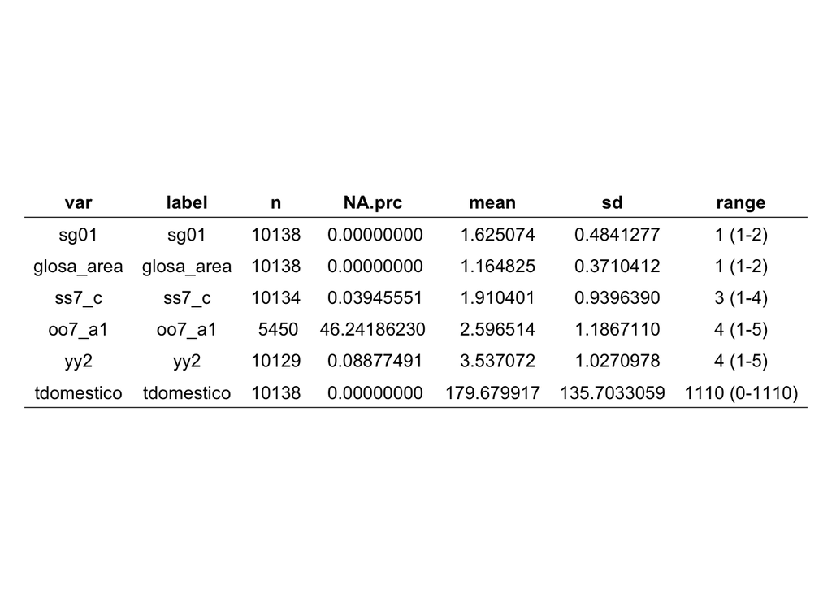

```r
# Crear tabla descriptiva
tabla_descriptivos <- ebs %>%
  select(sg01, glosa_area, ss7_c, oo7_a1, yy2, tdomestico) %>%
  sjmisc::descr(show = c("label", "range", "mean", "sd", "NA.prc", "n")) %>%
  as.data.frame()

library(ggpubr)
# Crear tabla con ggtexttable
tabla_plot <- ggtexttable(
  tabla_descriptivos,
  rows = NULL, # Sin nombres de filas
  theme = ttheme("light")
)

# Mostrar tabla como un gráfico
print(tabla_plot)
```

**Análisis**

1. **Relación entre frecuencia de ansiedad (ss7_c) y dificultad para llegar a fin de mes (yy2).**

   Hipótesis:

   H₀: cor(ss7_c, yy2) = 0

   H₁: cor(ss7_c, yy2) ≠ 0

   ```r
   #correlación entre ordinales
   cor.test(ebs$ss7_c, ebs$yy2, method = "spearman", use = "pairwise.complete.obs")
   ```

   ```
       Spearman's rank correlation rho

   data:  ebs$ss7_c and ebs$yy2
   S = 1.4542e+11, p-value < 2.2e-16
   alternative hypothesis: true rho is not equal to 0
   sample estimates:
         rho
   0.1593942
   ```

   A partir del cálculo de la correlación entre la frecuencia de ansiedad (ss7_c) y la dificultad para llegar a fin de mes (yy2), se observó una asociación positiva de magnitud pequeña (r = 0.159), estadísticamente significativa (p < 0.05). Este resultado permite rechazar la hipótesis nula de no asociación con un nivel de confianza del 95% y 99%, lo que confirma la existencia de una relación entre estas variables.

   El coeficiente positivo sugiere que, a medida que aumenta la dificultad para llegar a fin de mes, también lo hace la frecuencia de ansiedad. Este hallazgo es consistente con estudios previos que indican que la inseguridad económica contribuye al aumento del estrés y la ansiedad, ya que la preocupación por los recursos financieros afecta negativamente el bienestar psicológico.

   A pesar de que la correlación es pequeña, su significancia estadística destaca la relevancia de la situación económica en la salud mental.

   **Figura 1.**

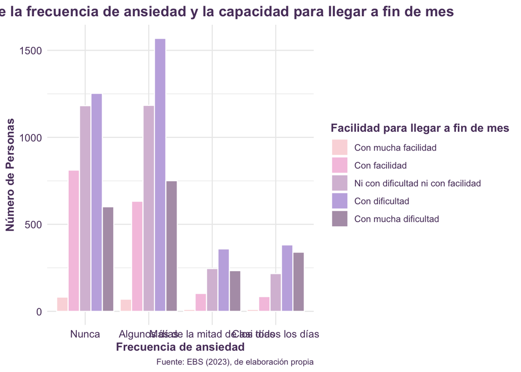

   ```r
   # ansiedad y capacidad de llegar a fin de mes
   ggplot(subset(ebs, !is.na(ss7_c) & !is.na(yy2)), aes(x = factor(ss7_c), fill = factor(yy2))) +
     geom_bar(position = "dodge", color = "white") +
     scale_fill_manual(
       values = c("1" = "#FADADD", "2" = "#F5C6E0", "3" = "#D8BFD8", "4" = "#C3B1E1", "5" = "#B39EB5"),
       labels = c(
         "1" = "Con mucha facilidad",
         "2" = "Con facilidad",
         "3" = "Ni con dificultad ni con facilidad",
         "4" = "Con dificultad",
         "5" = "Con mucha dificultad"
       )
     ) +
     labs(
       title = "Relación entre la frecuencia de ansiedad y la capacidad para llegar a fin de mes",
       x = "Frecuencia de ansiedad",
       y = "Número de Personas",
       fill = "Facilidad para llegar a fin de mes",
       caption = "Fuente: EBS (2023), de elaboración propia"
     ) +
     scale_x_discrete(labels = c(
       "1" = "Nunca",
       "2" = "Algunos días",
       "3" = "Más de la mitad de los días",
       "4" = "Casi todos los días"
     )) +
     theme_minimal() +
     theme(
       plot.title = element_text(face = "bold", size = 14, hjust = 0.5, color = "#5A3E6B"),
       axis.text.x = element_text(size = 10, color = "#5A3E6B"),
       axis.text.y = element_text(size = 10, color = "#5A3E6B"),
       axis.title = element_text(face = "bold", color = "#5A3E6B"),
       legend.title = element_text(face = "bold", color = "#5A3E6B"),
       legend.text = element_text(color = "#5A3E6B"),
       plot.caption = element_text(hjust = 1, size = 8, color = "#5A3E6B")
     )
   ```

   La *Figura 1* muestra que a mayor frecuencia de ansiedad, aumenta la proporción de personas que reportan dificultades para llegar a fin de mes. Quienes nunca sienten ansiedad tienen mayor representación en las categorías de facilidad económica, mientras que quienes la experimentan casi todos los días tienden a reportar mayores dificultades. Esto sugiere una posible relación entre ansiedad y percepción de dificultades económicas, la cual fue evidenciada ya en la correlación previamente calculada.
2. **Relación entre frecuencia de ansiedad (ss7_c) e inseguridad/inestabilidad laboral (007_a1)**

   Hipótesis

   H₀: cor(ss7_c, oo7_a1) = 0

   H₁: cor(ss7_c, oo7_a1) ≠ 0

   ```r
   cor.test(ebs$ss7_c, ebs$oo7_a1, method = "spearman", use = "pairwise.complete.obs")
   ```

   ```
       Spearman's rank correlation rho

   data:  ebs$ss7_c and ebs$oo7_a1
   S = 2.4408e+10, p-value = 3.013e-12
   alternative hypothesis: true rho is not equal to 0
   sample estimates:
          rho
   0.09433783
   ```

   A partir del cálculo de la correlación entre la frecuencia de ansiedad (ss7_c) y el temor a perder el empleo (oo7_a1), se observó una asociación positiva de magnitud pequeña (r = 0.094), estadísticamente significativa (p < 0.05). Este resultado permite rechazar la hipótesis nula de no asociación con un nivel de confianza del 95% y 99%, lo que confirma la existencia de una relación entre estas variables.

   El coeficiente positivo indica que, a mayor temor a perder el empleo, también se incrementa la frecuencia de ansiedad. Este hallazgo es consistente con la literatura que señala que la inseguridad laboral es un factor importante en el aumento del estrés y la ansiedad, ya que el miedo a la pérdida del empleo genera incertidumbre y preocupación, afectando el bienestar emocional de los individuos.

   Aunque la correlación es pequeña, su significancia estadística resalta la importancia de la inestabilidad laboral como un factor relevante en la salud mental de las personas.
3. **Relación entre ansiedad (ss7_c) y género (sg01)**

   H₀: cor(ss7_c, sg01) = 0

   H₁: cor(ss7_c, sg01) ≠ 0

   ```r
   #correlación punto biserial
   cor.test(ebs$ss7_c, ebs$sg01, method = "pearson", use = "pairwise.complete.obs")
   ```

   ```
       Pearson's product-moment correlation

   data:  ebs$ss7_c and ebs$sg01
   t = 13.299, df = 10132, p-value < 2.2e-16
   alternative hypothesis: true correlation is not equal to 0
   95 percent confidence interval:
    0.1117928 0.1500651
   sample estimates:
         cor
   0.1309778
   ```

   El coeficiente positivo indica que, en promedio, las mujeres tienden a experimentar niveles de ansiedad más altos en comparación con los hombres. Aunque la correlación es pequeña, su significancia estadística sugiere que el género tiene una influencia en los niveles de ansiedad, lo que podría reflejar desigualdades estructurales en las condiciones de vida y trabajo. Las mujeres enfrentan mayores desafíos en varios aspectos de la vida, lo que podría contribuir a un mayor nivel de ansiedad en comparación con los hombres.

   Este hallazgo subraya la importancia de considerar el género como un factor relevante en la salud mental, especialmente en contextos de desigualdad social y laboral.

   **Figura 2.**

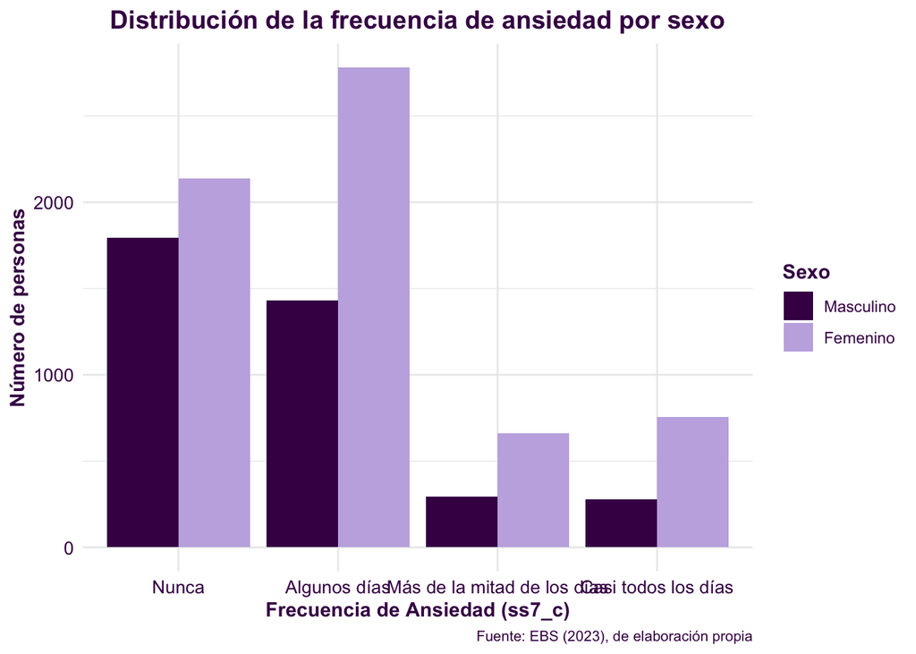

   ```r
   # ansiedad por sexo
   ggplot(subset(ebs, !is.na(ss7_c) & !is.na(sg01)), aes(x = factor(ss7_c), fill = factor(sg01))) +
     geom_bar(position = "dodge") +
     scale_fill_manual(
       values = c("1" = "#440154", "2" = "#C3B1E1"), # Colores morado y rosado
       labels = c("1" = "Masculino", "2" = "Femenino")
     ) +
     labs(
       title = "Distribución de la frecuencia de ansiedad por sexo",
       x = "Frecuencia de Ansiedad (ss7_c)",
       y = "Número de personas",
       fill = "Sexo",
       caption = "Fuente: EBS (2023), de elaboración propia"
     ) +
     scale_x_discrete(labels = c(
       "1" = "Nunca",
       "2" = "Algunos días",
       "3" = "Más de la mitad de los días",
       "4" = "Casi todos los días"
     )) +
     theme_minimal() +
     theme(
       plot.title = element_text(face = "bold", size = 14, hjust = 0.5, color = "#440154"),
       axis.text.x = element_text(size = 10, color = "#440154"),
       axis.text.y = element_text(size = 10, color = "#440154"),
       axis.title = element_text(face = "bold", color = "#440154"),
       legend.title = element_text(face = "bold", color = "#440154"),
       legend.text = element_text(color = "#440154"),
       plot.caption = element_text(hjust = 1, size = 8, color = "#440154")
     )
   ```

   **Correlación tetratórica entre ss7_c_recode y sg01**

   Tras realizar una recodificación de ss7_C se realiza una correlación tetratórica para profundizar el análisis de la relación entre sexo y nivel de ansiedad.

   ```r
   # Recodificación de la variable ss7_c a una nueva variable ss7_c_recode
   ebs <- ebs %>%
     mutate(
       ss7_c_recode = case_when(
         ss7_c == 1 ~ 1,  # Baja ansiedad: Nunca
         ss7_c == 2 ~ 1,  # Baja ansiedad: Algunos días
         ss7_c == 3 ~ 2,  # Alta ansiedad: Más de la mitad de los días
         ss7_c == 4 ~ 2,  # Alta ansiedad: Casi todos los días
         TRUE ~ NA_real_  # Asignar NA en caso de valores faltantes
       ))

   # cálculo de correlación
   tetratorica_ansiedad_sexo <- ebs %>%
     dplyr::select(ss7_c_recode, sg01)

   psych::tetrachoric(tetratorica_ansiedad_sexo, na.rm = T)
   ```

   ```
   Call: psych::tetrachoric(x = tetratorica_ansiedad_sexo, na.rm = T)
   tetrachoric correlation
                ss7__ sg01
   ss7_c_recode 1.00
   sg01         0.17  1.00

    with tau of
   ss7_c_recode         sg01
           0.85        -0.32
   ```

   La **correlación tetracórica** entre el sexo y los niveles de ansiedad es positiva pero débil (r=0.17), sugiriendo una relación baja entre ambas variables.

   **Prueba Chi-cuadrado**

   ```r
   chi_results1 <- chisq.test(ebs$ss7_c_recode, ebs$sg01)

   chi_results1
   ```

   ```
       Pearson's Chi-squared test with Yates' continuity correction

   data:  ebs$ss7_c_recode and ebs$sg01
   X-squared = 79.231, df = 1, p-value < 2.2e-16
   ```

   La prueba Chi-cuadrado muestra una asociación estadísticamente significativa (p<0.001), indicando que el sexo y la ansiedad están relacionados de manera no aleatorias. Las mujeres parecen estar más representadas en niveles altos de ansiedad, lo que podría indicar diferencias de género en cómo se perciben o experimentan estos estados.

   Se puede decir que aunque la correlación es débil, el resultado es significativo y refuerza la necesidad de investigar más sobre cómo el género influye en la ansiedad.

   **Cálculo de Phi**

   ```r
   chi_results1 <- chisq.test(ebs$ss7_c_recode, ebs$sg01)
   n <- na.omit(ebs %>% select(ss7_c_recode, ebs$sg01)) %>% nrow()
   # Cálculo de Phi
   phi <- sqrt(chi_results1$statistic / n)
   phi
   ```

   ```
    X-squared
   0.08842118
   ```

   En este caso, el valor de Phi (0.0884) sugiere que la relación entre las variables (`ss7_c_recode` y `sg01`) es débil. Aunque la prueba de chi-cuadrado muestra una asociación estadísticamente significativa (p < 0.001), el valor de Phi indica que la fuerza de esa asociación es baja. Esto significa que, aunque hay una diferencia significativa en la distribución, la magnitud de la asociación es pequeña.

   **Tabla 3.** **Tabla cruzada entre ss7_recode y sg01**

   ```r
   sjPlot::tab_xtab(ebs$ss7_c_recode, ebs$sg01, show.row.prc = TRUE)
   ```

   | ss7_c_recode | sg01 |  | Total |  |
   | --- | --- | --- | --- | --- |
   |  | 1 | 2 |  |  |
   | 1 | 3225 39.6 % | 4919 60.4 % |  | 8144 100 % |
   | 2 | 573 28.8 % | 1417 71.2 % | 1990 100 % |  |
   | Total | 3798 37.5 % | 6336 62.5 % | 10134 100 % |  |
   | χ<sup>2</sup>=79.231 · df=1 · &phi=0.089 · p=0.000 |  |  |  |  |

   H₀: cor(ss7_c, tdomestico) = 0

   H₁: cor(ss7_c, tdomestico) ≠ 0

   ```r
   cor.test(ebs$ss7_c, ebs$tdomestico_horas, method = "pearson", use = "pairwise.complete.obs")
   ```

   ```
       Pearson's product-moment correlation

   data:  ebs$ss7_c and ebs$tdomestico_horas
   t = 7.2792, df = 10132, p-value = 3.609e-13
   alternative hypothesis: true correlation is not equal to 0
   95 percent confidence interval:
    0.05273147 0.09146906
   sample estimates:
          cor
   0.07212747
   ```

   A partir del cálculo de la correlación entre la frecuencia de ansiedad (ss7_c) y la carga en el trabajo doméstico (tdomestico), se observó una asociación positiva de magnitud pequeña (r = 0.072), estadísticamente significativa (p < 0.05). Este resultado permite rechazar la hipótesis nula de no asociación con un nivel de confianza del 95% y 99%, lo que confirma la existencia de una relación entre estas variables.

   El coeficiente positivo indica que, a mayor carga en el trabajo doméstico, también se incrementan los niveles de ansiedad. Este hallazgo es consistente con estudios previos que sugieren que la sobrecarga en las tareas domésticas, especialmente en contextos de desigualdad de género, puede generar estrés y preocupación, factores asociados a mayores niveles de ansiedad.

   **Figura 3. Histograma para ilustrar diferencia por género**

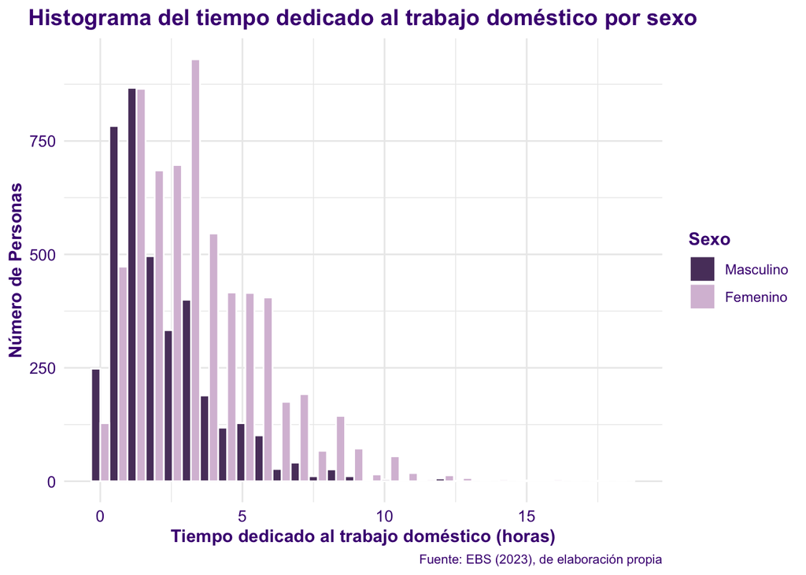

   ```r
   #tdomestico histograma

   ggplot(ebs %>% filter(!is.na(sg01) & !is.na(tdomestico_horas)),
          aes(x = tdomestico_horas, fill = factor(sg01))) +
     geom_histogram(position = "dodge", bins = 30, color = "white") +
     scale_fill_manual(
       values = c("1" = "#5A3E6B", "2" = "#D8BFD8"),
       labels = c("1" = "Masculino", "2" = "Femenino")
     ) +
     labs(
       title = "Histograma del tiempo dedicado al trabajo doméstico por sexo",
       x = "Tiempo dedicado al trabajo doméstico (horas)",
       y = "Número de Personas",
       fill = "Sexo",
       caption = "Fuente: EBS (2023), de elaboración propia"
     ) +
     theme_minimal() +
     theme(
       plot.title = element_text(face = "bold", size = 14, hjust = 0.5, color = "#4B0082"),
       axis.text.x = element_text(size = 10, color = "#4B0082"),
       axis.text.y = element_text(size = 10, color = "#4B0082"),
       axis.title = element_text(face = "bold", color = "#4B0082"),
       legend.title = element_text(face = "bold", color = "#4B0082"),
       legend.text = element_text(color = "#4B0082"),
       plot.caption = element_text(hjust = 1, size = 8, color = "#4B0082")
     )
   ```

Para enriquecer el análisis del trabajo doméstico se elaboró un histograma para observar la distribución de trabajo doméstico por sexo (*Figura 3*). El histograma muestra el tiempo dedicado al trabajo doméstico por sexo. Se puede observar que las mujeres dedican significativamente más tiempo al trabajo doméstico que los hombres, con una mayor concentración en rangos de 2 a 6 horas. Los hombres, en su mayoría, dedican menos de 2 horas. Esto evidencia una desigualdad de género en la distribución del trabajo doméstico, lo que puede influir en una mayor presencia de ansiedad observada en los análisis anteriores.

```r
cor.test(ebs$ss7_c, ebs$glosa_area, method = "pearson", use = "pairwise.complete.obs")
```

```
    Pearson's product-moment correlation

data:  ebs$ss7_c and ebs$glosa_area
t = -5.6288, df = 10132, p-value = 1.863e-08
alternative hypothesis: true correlation is not equal to 0
95 percent confidence interval:
 -0.07522139 -0.03640264
sample estimates:
        cor
-0.05583311
```

**Discusión de resultados**

A partir del análisis, se puede afirmar que aunque todas las hipótesis son confirmadas en cuanto a la existencia de relaciones significativas, los efectos encontrados tienden a ser de magnitud pequeña, lo que indica que existen otros factores que también podrían estar influyendo en los niveles de ansiedad que no se capturan completamente en este análisis.

**Conclusión**

A modo de conclusión, el presente trabajo analizó la relación entre la frecuencia de ansiedad y diversos factores sociodemográficos y socioeconómicos. Los resultados evidenciaron asociaciones significativas entre la ansiedad y las variables estudiadas, aunque en su mayoría con magnitudes de efecto pequeñas.

En cuanto a las limitaciones, estas se articulan en dos principales esferas. Por un lado, las asociadas a la representatividad muestral de la EBS 2023, ya que no incluye a personas trabajadoras menores de 18 años ni a viviendas colectivas o de temporada, lo que podría afectar la correcta representación de los datos. Por otro lado, se identifican limitaciones propias del análisis realizado en esta investigación. En primer lugar, las correlaciones, aunque estadísticamente significativas, presentaron magnitudes pequeñas, como en el caso de las relaciones entre ansiedad y factores socioeconómicos, lo que indica que estas asociaciones son débiles. En segundo lugar, el uso de pairwise para manejar los datos faltantes, aunque necesario, podría haber introducido sesgos si los datos ausentes no son aleatorios o siguen patrones sistemáticos. Además, variables adicionales, como el nivel educativo o las redes de apoyo social, podrían haber enriquecido los resultados obtenidos.

**Bibliografía**

Alvarado, E., & Alvarado-García, P. (2020). GESTIÓN DE LAS FINANZAS PERSONALES y ANSIEDAD FINANCIERA EN TIEMPOS DE COVID-19. *Redieluz*, 10(2), 116-124.https://www.researchgate.net/profile/Daniel-Polanco-2/publication/353463958_Variacion_de_la_comunidad_fitoplanctonica_en_piscinas_de_cultivo_semi-intensivo_de_Litopenaeus_vannamei_en_el_lago_de_Maracaibo_Venezuela/links/60feddae2bf3553b29141bd3/Variacion-de-la-comunidad-fitoplanctonica-en-piscinas-de-cultivo-semi-intensivo-de-Litopenaeus-vannamei-en-el-lago-de-Maracaibo-Venezuela.pdf#page=116

De Políticas Públicas En Salud, I.-. I. (s. f.). Informe OMS: *Más de un millón de chilenos sufre ansiedad y 850 mil tienen depresión.* IPSUSS - Instituto de Políticas Públicas En Salud. https://ipsuss.cl/analisis-y-estudios/salud-mental/informe-oms-mas-de-un-millon-de-chilenos-sufre-ansiedad-y-850-mil

INJUV. (2022). *Salud Mental*. Ministerio de Derecho Social y Familia. https://recursoshdt.injuv.gob.cl/wp-content/uploads/2022/10/2-ansiedad-cifras-de-interes-2023.pdf

Instituto Nacional de Estadística [INE]. (2016). Encuesta Nacional sobre Uso del Tiempo: “Documento de principales Resultados ENUT 2015”. En www.ine.gob.cl. Departamento de Estudios Sociales Instituto Nacional de Estadísticas. Recuperado 28 de noviembre de 2024, de https://www.ine.gob.cl/estadisticas/sociales/genero/uso-del-tiempo

Londoño, N. H., Marín, C. A., Juárez, F., Palacio, J., Muñiz, O., Escobar, B., Herrón, I., Agudelo, D., Lemos, M., Toro, B. E., Ochoa, N. L., Hurtado, M. H., Gómez, Y., Uribe, A. F., Rojas, A. L., Pinilla, M. L., Villa-Roel, D., Villegas, M. J., Arango, A. L., … López, I. C. (2010). Factores de riesgo psicosociales y ambientales asociados a trastornos mentales. *Suma Psicológica,* 17(1), 59–68. http://www.scielo.org.co/scielo.php?script=sci_arttext&pid=S0121-43812010000100005&lng=en&tlng=es

Organización Internacional del Trabajo. (2004). La seguridad económica mundial en crisis Un nuevo informe de la OIT descubre un “mundo lleno de ansiedad e ira”.https://www.ilo.org/es/publications/la-seguridad-economica-mundial-en-crisis-un-nuevo-informe-de-la-oit

Organización Mundial de la Salud. (2022). *Trastornos mentales. Organizacion mundial de la Salud.* https://www.who.int/es/news-room/fact-sheets/detail/mental-disorders

Torales, J., Insaurralde, A., Ríos-González, C., Ruíz Díaz, N., Navarro, R., Ayala-Servín, N., Almirón-Santacruz, J., Gamarra-Vega, E., Segovia-Cañete, A., Vera-Toledo, H., Barrios, I., Castaldelli-Maia, J. M., Ventriglio, A., & O’Higgins, M. (2021). *Asociación entre la procedencia del área urbana o rural y el desarrollo de trastornos del espectro depresivo: una experiencia desde la telepsiquiatría.* SciELO.http://scielo.iics.una.py/scielo.php?script=sci_arttext&pid=S2072-81742021000200054

Vega Montiel, A. (2007). *Por la visibilidad de las amas de casa: rompiendo la invisibilidad del trabajo doméstico.* Scielo.org. https://www.scielo.org.mx/pdf/polcul/n28/n28a8.pdf

Vicente, B., Saldivia, S., & Pihán, R. (2016). *Prevalencias y brechas hoy; salud mental mañana.* Scielo.org. https://www.scielo.cl/scielo.php?script=sci_arttext&pid=S1726-569X2016000100006

Clavería, J. A. O., Ernenwein, D. H., Sarto, A. C. G., Fuentes, E. M. C., Vallejo, P. Á., Bueno, M. T. B., & Clavería, M. J. O. (2023). *Definición de la ansiedad en el trabajo.* Dialnet. https://dialnet.unirioja.es/servlet/articulo?codigo=9230663